# The lcmm Package

# Comparing models

We want to be able to select the model with the correct number of classes (i.e., the model that best fits the data). The AIC and BIC numbers are most helpful. A lower number shows a better fit. The `summarytable()` function allows one to compare AIC and BIC of multiple models:

```r
# make table with results for the 3 models:
summarytable(lcga1, lcga2, lcga3, which = c("AIC", "BIC", "entropy","ICL")) %>% kable()
```

```
##            AIC      BIC   entropy     ICL1     ICL2
## lcga1 2298.643 2306.458 1.0000000 2306.458 2306.458
## lcga2 1762.911 1778.542 0.9973378 1778.727 1778.611
## lcga3 1734.593 1758.040 0.8918353 1769.923 1770.155
```

|  | AIC | BIC | entropy | ICL1 | ICL2 |
| --- | --- | --- | --- | --- | --- |
| lcga1 | 2298.643 | 2306.458 | 1.0000000 | 2306.458 | 2306.458 |
| lcga2 | 1762.911 | 1778.542 | 0.9973378 | 1778.727 | 1778.611 |
| lcga3 | 1734.593 | 1758.040 | 0.8918353 | 1769.923 | 1770.155 |

You can also plot the results

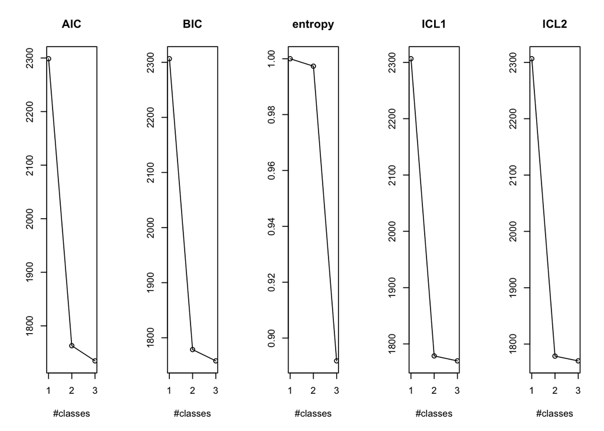

```r
# Produce summary plots
summaryplot(lcga1, lcga2, lcga3, which = c("AIC", "BIC", "entropy","ICL"))
```

In our case we know the data contains two classes, but the AIC and BIC are lower for the 3-class model. None of these models are a very good fit. So let’s try GMM models instead:

# GMM Models

```r
gmm1 <- hlme(y ~ time, subject = "ID", random=~1, ng=1, data=mydata)
gmm2 <- gridsearch(rep = 100, maxiter = 10, minit = gmm1,
                   hlme(y ~ time, subject = "ID", random=~1,
                        ng = 2, data = mydata, mixture = ~ time,
                        nwg=T))
gmm3 <- gridsearch(rep = 100, maxiter = 10, minit = gmm1,
                   hlme(y ~ time, subject = "ID", random=~1,
                        ng = 3, data = mydata, mixture = ~ time,
                        nwg=T))
```

Then we compare the models in a new summary table:

```r
summarytable(gmm1, gmm2, gmm3, which = c("AIC", "BIC", "entropy","ICL")) %>% kable()
```

```
##           AIC      BIC   entropy     ICL1     ICL2
## gmm1 2091.948 2102.369 1.0000000 2102.369 2102.369
## gmm2 1726.681 1747.522 0.9883817 1748.328 1748.018
## gmm3 1701.438 1732.700 0.8857808 1745.248 1744.276
```

|  | AIC | BIC | entropy | ICL1 | ICL2 |
| --- | --- | --- | --- | --- | --- |
| gmm1 | 2091.948 | 2102.369 | 1.0000000 | 2102.369 | 2102.369 |
| gmm2 | 1726.681 | 1747.522 | 0.9883817 | 1748.328 | 1748.018 |
| gmm3 | 1701.438 | 1732.700 | 0.8857808 | 1745.248 | 1744.276 |

Even now we see that the 3 class model is the best fit. Definitely not correct, so we’ll try the third and final type of model.

# Running GGM-2 models (small adjustment from GMM-1 models)

Note the only change is random is set the `random` argument to “~1+time”

```r
gmm1_2 <- hlme(y ~ time, subject = "ID", random=~1 + time, ng = 1,
               data =mydata)
gmm2_2 <- gridsearch(rep = 100, maxiter = 10, minit = gmm1_2,
                     hlme(y ~ time, subject = "ID", random=~1 + time,
                          ng = 2, data = mydata, mixture = ~ time, nwg=T))
gmm3_2 <- gridsearch(rep = 100, maxiter = 10, minit = gmm1_2,
                     hlme(y ~ time, subject = "ID", random=~1+time,
                          ng = 3, data = mydata, mixture = ~ time,
                          nwg=T))


summarytable(
  gmm1_2, gmm2_2, gmm3_2, gmm1, gmm2, gmm3, lcga1, lcga2, lcga3,
  which=c("G", "loglik", "npm", "AIC", "BIC", "%class")
)
```

```
##        G     loglik npm      AIC      BIC %class1 %class2 %class3
## gmm1_2 1  -857.5434   6 1727.087 1742.718     100
## gmm1   1 -1041.9742   4 2091.948 2102.369     100
## lcga1  1 -1146.3214   3 2298.643 2306.458     100
## gmm2_2 2  -828.7719  10 1677.544 1703.595      50      50
## gmm2   2  -855.3405   8 1726.681 1747.522      50      50
## lcga2  2  -875.4555   6 1762.911 1778.542      50      50
## gmm3_2 3  -825.9740  14 1679.948 1716.420      18      50      32
## gmm3   3  -838.7191  12 1701.438 1732.700      35      45      20
## lcga3  3  -858.2967   9 1734.593 1758.040      19      48      33
```

Finally, we see the two class GMM-2 model is the best fit

# Visualising the GMM-2 two-class model

The code to create this plot isn’t shown here. But first you use the `lcmm::predictY()` function to create a data frame of predictions from the model. And then use that to plot a line in `ggplot`. You can see the linear model fits these data well.

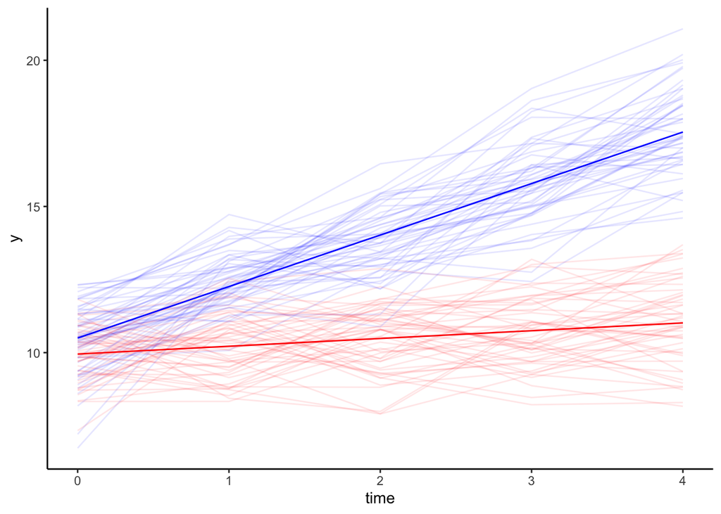

This is very good but quite restrictive:

- Our outcome (y) is normally distributed
- The relationship between time and y is linear

Trajectories in the real world may not meet these assumptions. The `lcmm` package has the `lcmm` function which allows for non-normally distributed data. And there are some clever tricks you can do for non-linear time-outcome relationships.

# lcmm function

This example used the `paquid` dataset, which is included in the `lccm` package. The first step is to centre the age around 65 and scale by 10. The tutorial says to do this to avoid numerical problems.

The outcome variable is *CESD*, which is the a scale of depressive symptoms. Exposure variables included in the model are age and gender (1=male, 0=female).

```r
paquid <- paquid %>% mutate(age65 = (age - 65)/10)
```

```r
mlin <- lcmm(
  CESD ~ age65*male,
  random=~ age65,
  subject='ID',
  data=paquid
) #link= linear
```

# Non-linear link functions

## The rescaled cumulative distribution function

The above example uses a linear link function by default. You can specify a non-linear function as per below. The rescaled cumulative distribution function (CDF) of a Beta distribution provides concave, convex or sigmoïd transformations between the marker and its underlying latent process.

```r
mbeta <- lcmm(
  CESD ~ age65*male,
  random=~ age65,
  subject = "ID",
  data=paquid,
  link = "beta"
)
```

## Quadratic I-Splines

The family of quadratic I-splines approximates any continuous increasing link function. It involves nodes that are distributed within the range of the marker. By default, 5 equidistant knots located in the marker range are used :

```r
mspl <- lcmm(
  CESD ~ age65*male,
  random=~ age65,
  subject='ID',
  data=paquid,
  link='splines'
)
```

The number of splines (or “knots”) and their spacing can be specified with a character string in the `link` argument. The number of nodes is first entered followed by -, then the location is specified with equi, quant or manual for respectively equidistant knots, knots at quantiles of the marker distribution or interior knots entered manually in argument intnodes. For example, 7-equi-splines means I-splines with 7 equidistant nodes, 6-quant-splines means I-splines with 6 nodes located at the quantiles of the marker distribution. The shortcut splines stands for 5-equi-splines.  
For an example with 5 knots placed at the quantiles:

```r
mspl5q <- lcmm(
  CESD ~ age65*male,
  random=~ age65,
  subject='ID',
  data=paquid,
  link='5-quant-splines'
)
```

# Selecting the best lcmm() model and visualising outputs

As before with the `hlme()` function example, comparing the goodness of fit measures (e.g. AIC and UACV), between models using the `summarytable()` function.

```r
summarytable(mlin,mbeta,mspl,mspl5q,which = c("loglik", "conv", "npm", "AIC"))
```

```
##           loglik conv npm      AIC
## mlin   -7056.652    1   8 14129.30
## mbeta  -6306.962    1  10 12633.92
## mspl   -6509.681    1  13 13045.36
## mspl5q -6320.085    1  13 12666.17
```

## Visualising the link functions

So if the linear function is linear, and beta and spline functions bend the line, what does that look like. Well, this:

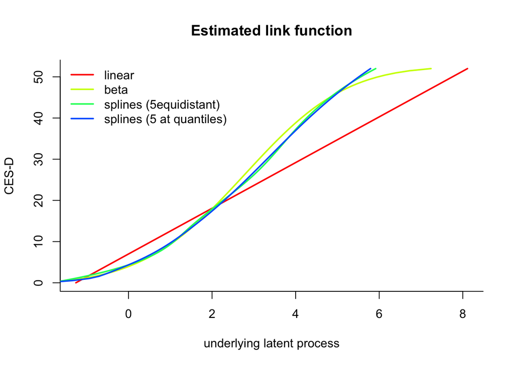

The straight line deviates quite a bit from the curved lines, suggesting the linear model is unlikely to be appropriate for our data.

You can use this code to get 95% confidence intervals of the lines:

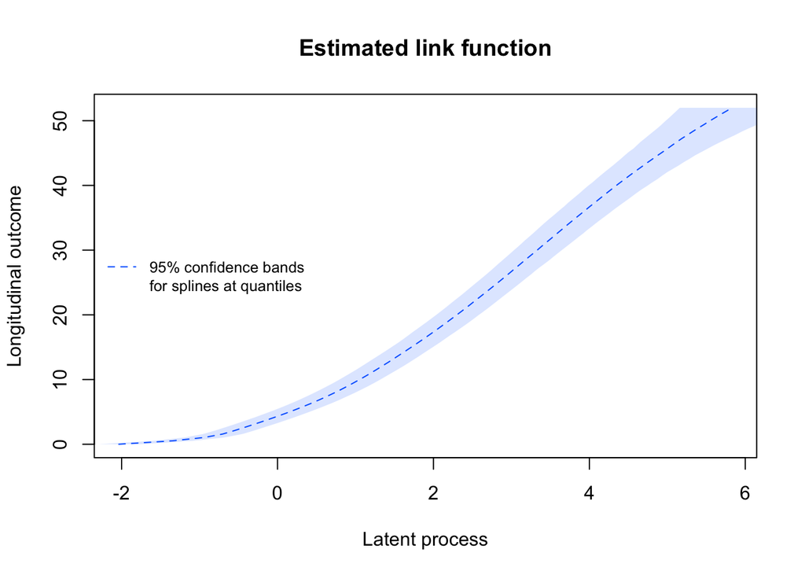

```r
linkspl5q <- predictlink(mspl5q,ndraws=2000)
plot(linkspl5q, col=col[4], lty=2, shades=TRUE)
legend(x="left", legend=c("95% confidence bands","for splines at quantiles"),lty=c(2,NA), col=c(col[4],NA), bty="n", lwd=1, cex=0.8)
```

# Multiple classes

If you want to add multiple classes to a model like this you can do something like the below code. Obviously this model does not fit the data well at all, but example code:

```r
mlin.2 <- lcmm(CESD ~ age65*male, subject = "ID", random=~1, ng=1, data=paquid)
mlin.2class <- gridsearch(rep=100, maxiter = 10, minit = mlin.2, lcmm(CESD ~ age65*male, subject = "ID", random = ~1, ng=2, data=paquid, mixture = ~age65*male))
```